# Имитационное моделирование

Лабораторная работа №1

Автор

принадлежность

Гашимов Кенан Мухтар оглы

Российский университет дружбы народов

# 1 Сведения об авторе

- ФИО: Гашимов Кенан Мухтар оглы
- Группа: НКНбд-01-23
- Студенческий билет: 1032235820
- Направление: Математика и компьютерные науки

# 2 Цель работы

Изучить процесс численного решения дифференциального уравнения, описывающего экспоненциальный рост, применяя язык Julia совместно с инструментами для обеспечения воспроизводимости научных вычислений (DrWatson, Literate, Quarto). Помимо этого, необходимо овладеть приёмами варьирования параметров модели, построения графиков и оформления результатов эксперимента.

# 3 Задание

1. Подготовка рабочего окружения (git, git-flow).
2. Развёртывание Julia и формирование проекта на базе DrWatson.
3. Реализация простейшей модели экспоненциального роста.
4. Переработка кода в литературную форму и получение выходных форматов.
5. Исследование модели при различных значениях параметров.

# 4 Теоретическое введение

Экспоненциальный рост представляет собой модель, в которой темп изменения некоторой величины прямо пропорционален её текущему значению. В математической записи это соответствует следующему обыкновенному дифференциальному уравнению:

$$\frac{du}{dt} = \alpha u, \quad u(0) = u_0,$$

где $u(t)$ обозначает изучаемую переменную (к примеру, размер популяции), $\alpha$ — параметр, характеризующий интенсивность роста, $u_0$ — значение в начальный момент времени.

Точное решение данного уравнения записывается как $u(t) = u_0 e^{\alpha t}$. Важной характеристикой такого процесса служит период удвоения $T_2 = \ln 2 / \alpha$, то есть промежуток времени, за который величина возрастает в два раза.

Применение библиотеки DifferentialEquations.jl для численного интегрирования даёт возможность анализировать динамику системы при разных наборах параметров, осуществлять сканирование по параметрам и сопоставлять численные результаты с аналитическими.

# 5 Выполнение лабораторной работы

## 5.1 1. Подготовка рабочего окружения

Убедимся в корректности SSH-соединения с GitHub.

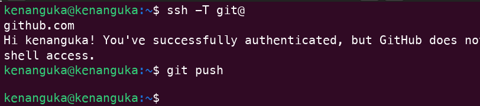

Рисунок 1: Тестирование SSH-соединения с GitHub

Ознакомимся со структурой каталогов курсового репозитория.

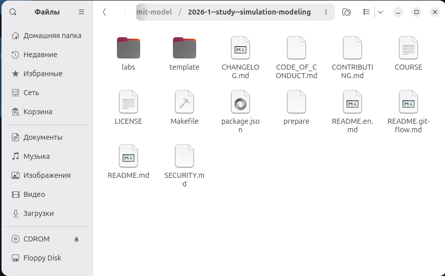

Рисунок 2: Иерархия каталогов курсового проекта

Произведём установку git-flow и выполним начальную конфигурацию.

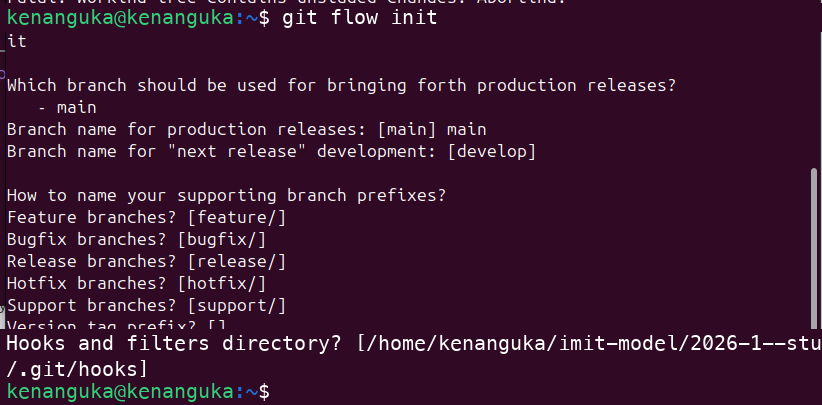

Рисунок 3: Развёртывание и конфигурация git-flow

Протестируем работу git-flow, создав и завершив feature-ветку.

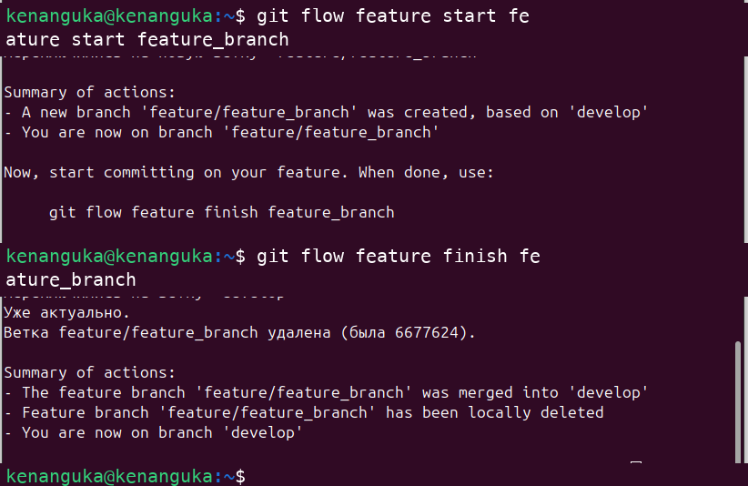

Рисунок 4: Тестирование feature-веток git-flow

## 5.2 2. Развёртывание Julia и формирование проекта DrWatson

Выполним установку Julia с помощью менеджера snap.

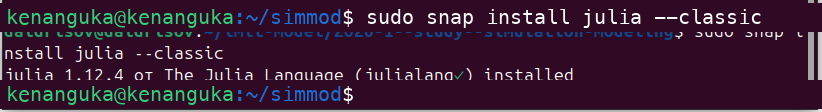

Рисунок 5: Развёртывание Julia посредством snap

Версия Julia 1.12.4 корректно установлена в системе.

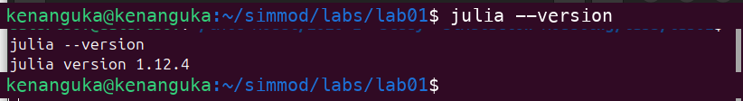

Рисунок 6: Подтверждение установки Julia 1.12.4

Сформируем проект DrWatson для выполнения лабораторных работ, запустив скрипт setup_project.jl.

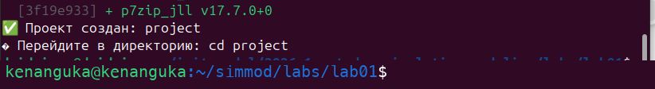

Рисунок 7: Формирование проекта DrWatson

Инициируем процесс добавления необходимых библиотек (DifferentialEquations, Plots, DataFrames, DrWatson и других) при помощи скрипта add_packages.jl.

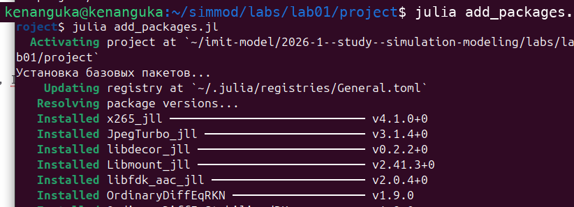

Рисунок 8: Добавление библиотек в проект

Все требуемые библиотеки добавлены и прошли предварительную компиляцию.

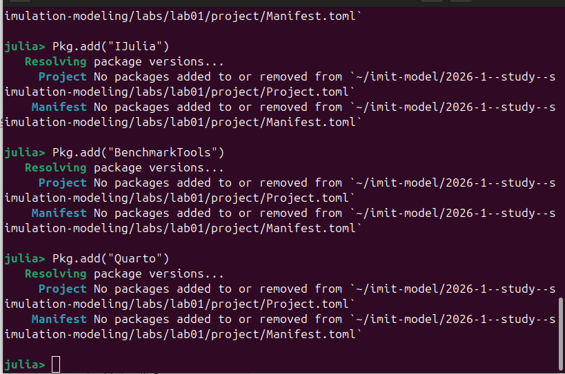

Рисунок 9: Успешное завершение добавления библиотек

Удостоверимся в работоспособности созданного проекта посредством скрипта test_setup.jl.

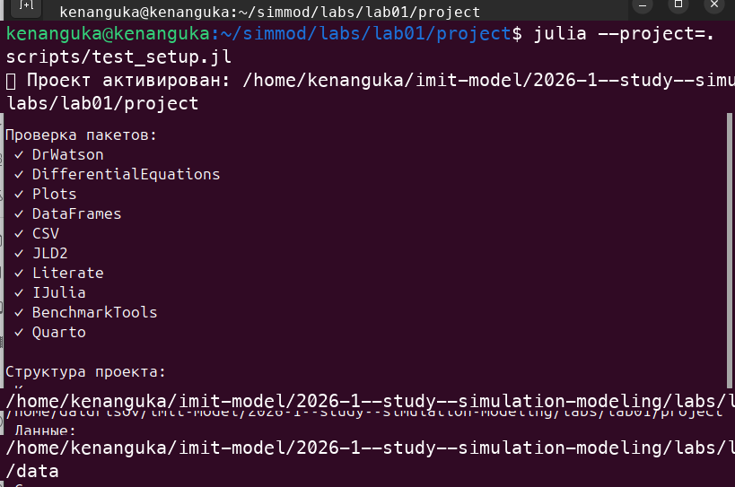

Рисунок 10: Верификация работоспособности проекта

## 5.3 3. Простейшая модель экспоненциального роста

Выполним скрипт 01_exponential_growth.jl, осуществляющий решение ОДУ экспоненциального роста для $\alpha = 0.3$. В результате получим график и табличные данные.

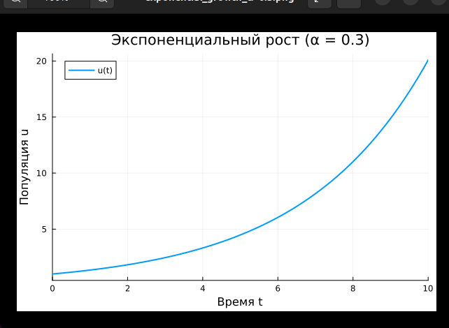

Рисунок 11: Итог работы скрипта: кривая экспоненциального роста

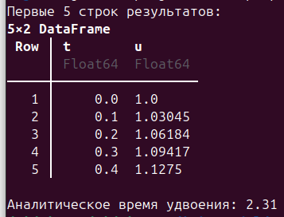

Итоги расчёта: таблица первых пяти записей DataFrame с приближённым решением, а также аналитически вычисленный период удвоения $T_2 = 2.31$.

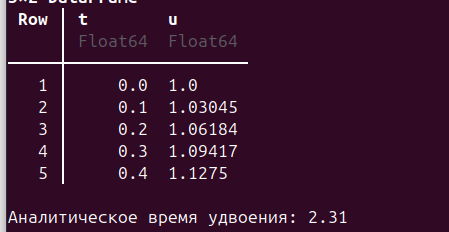

Рисунок 13: Вычислительные итоги и период удвоения

## 5.4 4. Получение выходных форматов

Запустим скрипт tangle.jl для преобразования литературного кода в производные форматы: чистый Julia-скрипт, блокнот Jupyter и документ Quarto.

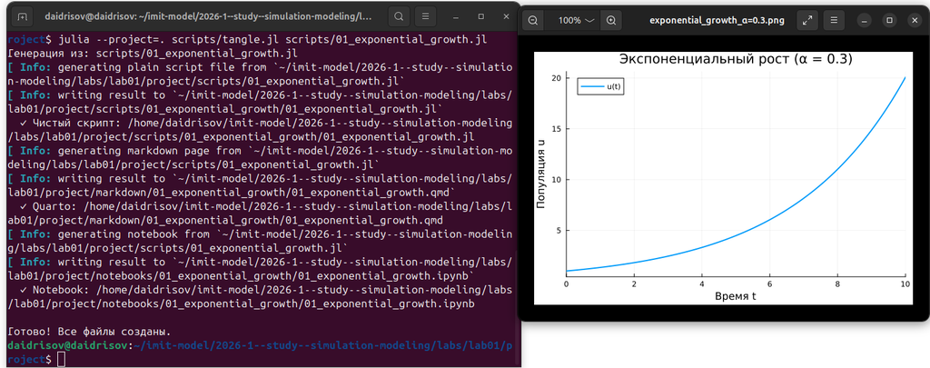

Рисунок 14: Преобразование литературного кода в производные форматы (tangle.jl)

Скрипт tangle.jl формирует все три выходных формата для каждого эксперимента.

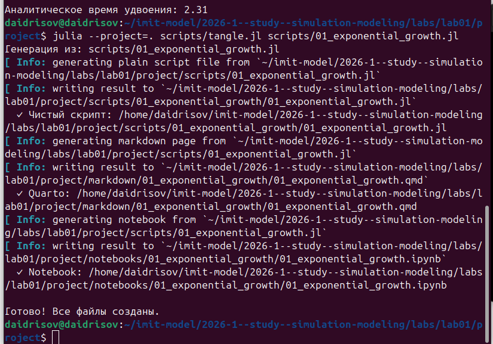

Рисунок 15: Полный журнал преобразования форматов